# Reproducible Research: Peer Assessment 1

## Loading and preprocessing the data

```r
if( !file.exists("activity.csv")){
unzip("activity.zip")
}
unzip("activity.zip")
data<-read.csv("activity.csv", header=TRUE)
names(data)
```

```
## [1] "steps"    "date"     "interval"
```

```r
head(data)
```

```
##   steps       date interval
## 1    NA 2012-10-01        0
## 2    NA 2012-10-01        5
## 3    NA 2012-10-01       10
## 4    NA 2012-10-01       15
## 5    NA 2012-10-01       20
## 6    NA 2012-10-01       25
```

```r
datana<- na.omit(data)
```

## What is mean total number of steps taken per day?

1. Calculate the total number of steps taken per day

```r
daily_steps<- aggregate( datana$steps, by= list(Steps.Date=datana$date), FUN="sum")
```

2. Histogram of the total number of steps taken each day

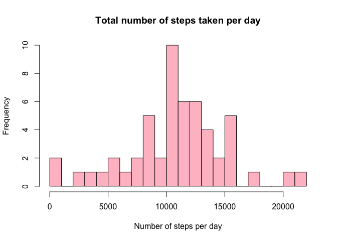

```r
hist(daily_steps$x, col="pink",
     breaks=20,
     main= "Total number of steps taken per day",
     xlab="Number of steps per day")
```

3. Mean and median number of steps taken each day

```r
mean_steps <- mean (daily_steps [,2])
print(mean_steps)
```

```
## [1] 10766.19
```

```r
median_steps <-median (daily_steps [,2])
print(median_steps)
```

```
## [1] 10765
```

## What is the average daily activity pattern?

[figure not shown]

```r
average<-aggregate(datana$steps, by= list(steps.interval=datana$interval), FUN="sum")
plot(average$steps.interval, average$x, type="l", col="purple", xlab="Intervals", ylab="Average number of steps taken")
```

2. Which 5-minute interval, on average across all the days in the dataset, contains the maximum number of steps?

```r
interval_max_steps <- average[which.max(average$x),]$steps.interval
interval_max_steps
```

```
## [1] 835
```

## Imputing missing values

1. Calculate and report the total number of missing values in the dataset

```r
totalNA<-sum(is.na(data$steps))
totalNA
```

```
## [1] 2304
```

2. Devise a strategy for filling in all of the missing values in the dataset. (use the mean/median for that day, or the mean for that 5-minute interval)

```r
meandata<-mean(datana$steps)
```

3. Create a new dataset that is equal to the original dataset but with the missing data filled in.

```r
data_in <- data
sum(is.na(data_in))
```

```
## [1] 2304
```

```r
data_in$steps[is.na(data_in$steps)] <- meandata
colSums(is.na(data_in))
```

```
##    steps     date interval
##        0        0        0
```

Let’s probe it works:

```r
sum(is.na(data_in))
```

```
## [1] 0
```

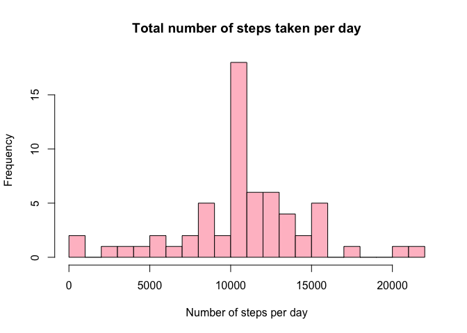

```r
daily_stepsna<- aggregate( data_in$steps, by= list(Steps.Da=data_in$date), FUN="sum")
hist(daily_stepsna$x, col="pink",
     breaks=20,
     main= "Total number of steps taken per day",
     xlab="Number of steps per day"
     )
```

### Comparative Histogram

[figure not shown]

4.1 . Mean and median number of steps taken each day of the filled data

```r
mean_steps1 <- mean (daily_stepsna [,2])
print(mean_steps1)
```

```
## [1] 10766.19
```

```r
median_steps1 <-median (daily_stepsna [,2])
print(median_steps1)
```

```
## [1] 10766.19
```

## Are there differences in activity patterns between weekdays and weekends?

1. Create a new factor variable in the dataset with two levels – “weekday” and “weekend” indicating whether a given date is a weekday or weekend day.

```r
data_in$date<-as.Date(data_in$date)
data_in$weekday<- weekdays(data_in$date)
data_in$day_type<-ifelse(data_in$weekday=="Saturday" |  data_in$weekday=="Sunday", "Weekend", "Weekday")
data_in$day_type <- factor(data_in$day_type)
```

2. Make a panel plot containing a time series plot (i.e. type = “l”) of the 5-minute interval (x-axis) and the average number of steps taken, averaged across all weekday days or weekend days (y-axis).

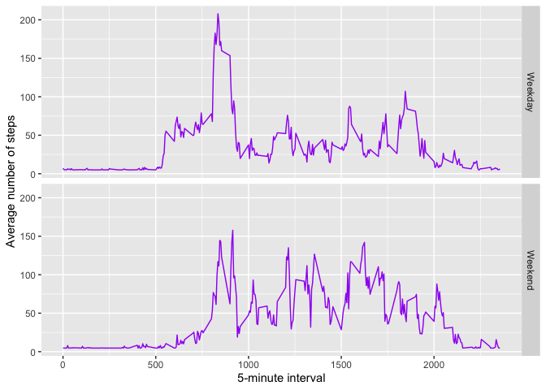

```r
average_days <- aggregate(steps ~ interval + day_type, data=data_in, mean)

library(ggplot2)

ggplot(average_days, aes(interval, steps)) +
    geom_line( colour="purple") +
    facet_grid(day_type ~ .) +
    xlab("5-minute interval") +
    ylab("Average number of steps")
```